Afra Kilic; November 2022

The Naive Bayes Classifier

Naive Bayes (Cestnik et al., 1987, Domingos and Pazzani, 1997, Soria et al., 2011) is a supervised non-linear machine learning (ML) algorithm to solve the classification problems especially with high dimensional training data sets. It uses a simple probabilistic approach based on the Bayes theorem with a strong assumption of conditional independence for every feature or variable. Naive Bayes classification is called “naive” because of this independency assumption between the variables. However, this simple probabilistic approach makes the naive Bayes algorithm very simple, applicable and effective to build the fast ML models that can make quick predictions.

To start with how naive Bayes classifier works in mathematical terms, let $Y$ denote a categorical response variable with two or more categories and ($X_{1}, X_{2}, ... , X_{p}$) be a set of $p$ predictors of $Y$. Then the posterior probability that a new case with observed predictors ($X_{1}, X_{2}, ... , X_{p}$) belongs to class $Y = y$ is

$$f(y|x_{1}, x_{2}, ..., x_{p}) = \frac{f(y)L(y|x_{1}, x_{2}, ..., x_{p})}{\sum_{\text{all } y^{'}} f(y^{'}) L(y^{'}|x_{1}, x_{2},...,x_{p})}$$
Naive Bayes classification makes the ‘naive’ assumptions about the likelihood function of $Y$:

- Predictor variables $X_{i}$ are **conditionally independent**, so

$$L(y|x_{1}, x_{2}, ..., x_{p}) = \prod_{i=1}^{p}f(x_{i}|y)$$

- For **categorical predictor variables**, the conditional probability mass function (pmf)

$$f(x_{i}|y) = P(X_{i} =x_{i}|Y = y)$$

is estimated by the sample proportion of observed $Y = y$ cases for which $X_{i} = x_{i}$.

- For **continuous predictor variables** $X{i}$, the conditional probability density function (pdf) $f(x_{i}|y)$ is defined by a Normal model:

$$X_{i}|(Y=y) \approx N(\mu_{iy}, \sigma_{iy}^2)$$
That is, within each category $Y=y$, $X_{i}$ is assumed to be normally distributed around a mean $\mu_{iy}$ with a standard deviation of $\sigma_{iy}$. $\mu_{iy}$ and $\sigma_{iy}$ are estimated based on the observed $X_{i}$ values in category $Y=y$.

Naive Bayes is an alternative way for the classical logistic regression which is also used to determine whether a sample belongs to a particular class, for instance, if an e-mail is spam or not. Basically, the two learning mechanisms work differently such that naive Bayes is a generative model and Logistic regression is a discriminative model. Particularly, naive Bayes models the joint distribution of the variable $X$ and the outcome $Y$, and then it predicts the posterior probability given as $P(Y|X)$. On the other hand, logistic regression directly models the posterior probability $P(Y|X)$ by learning the input to output mapping by minimizing the error.

Another very important difference between them is that unlike the logistic regression model with

$$log(\frac{\pi}{1-\pi}) = \beta_{0} + \beta_{1}X_{1} + ... + \beta_{k}X_{p},$$

naive Bayes does not have regression coefficients $\beta_{i}$. So, naive Bayes does not provide information regarding the relationship between the predictor variables and the outcome variable.

Furthermore, naive Bayes has a higher bias and low variance whereas logistic regression has low bias and higher variance. As a result, compared to logistic regression, naive Bayes gives better predictions when the training data is small. Also, for the logistic regression classifiers when moving from smaller data sets and low complexity to larger data sets and higher model complexity; predictive power of the model increases with larger data but decreases with higher model complexity (Tsangaratos and Ilia, 2016). This phenomenon could be explained by the fact that logistic regression classifiers memorize the training data rather than learning to generalize from trend such that these models can exaggerate minor fluctuations in the data and perform worse in the prediction phase. Lastly, unlike the logistic regression classifiers, naive Bayes can classify categorical response variables with more than two categories.

Hence, for multi-class prediction problems with high dimensional data sets (i.e., spam filtration, sentimental analysis, article classificiation), naive Bayes provides more advantages over the classical regression classification. However, naive Bayes cannot learn the interactions between the conditioning variables and its performance depends on the absence of multicolliniarity which is not always the case in the real life (Tsangaratos and Ilia, 2016).

Throughout the present work, I will try to explain how naive Bayes mechanism works and why it is called “naive” with a real data example.

Loading required packages

```r
# Load packages
library(bayesrules)
library(rstanarm)
library(bayesplot)
library(tidyverse)
library(tidybayes)
library(broom.mixed)
library(e1071)
library(caTools)
library(caret)
library(janitor)
library(ggplot2)
library(ggpubr)
```

The Dataset

Iris dataset is a multivariate dataset originally introduced by British statistician and biologist Ronald Fisher in 1963. It gives the measurements of sepal length and width; petal length and width in centimeters, respectively for 50 flowers from each of 3 species of Iris (Iris Setosa, Iris Virginica, Iris Versicolor).

```r
# Load Data
data(iris)
```

```r
iris %>%
  tabyl(Species)
```

```
##     Species  n   percent
##      setosa 50 0.3333333
##  versicolor 50 0.3333333
##   virginica 50 0.3333333
```

Random categorical data generation

As Iris dataset does not contain any categorical data, I generated a random categorical variable to also depict how naive Bayes uses categorical data for classification. Assume, some of the Iris flowers are spotted and some of them are not. This new categorical variable indicates whether the flower is spotted ($1$) or not ($0$). For each three-species, probability of observing a spotted flower is different. Assume the probability of observing spotted flowers is as follows;

- Setosa: 64%
- Versicolor: 47%
- Virginica: 13%

Based on these probabilities the following categorical variable called spotted is generated:

```r
#categorical data generation
set.seed(12)

setosa_spot <- factor(sample( c(1,0), 50, replace=TRUE, prob=c(0.6356784, 0.3643216)))
versicolor_spot <- factor(sample( c(1,0), 50, replace=TRUE, prob=c(0.46789056543, 0.5321094)))
virginica_spot <- factor(sample( c(1,0), 50, replace=TRUE, prob=c(0.1345654635, 0.8654345)))

spotted <- c(setosa_spot, versicolor_spot, virginica_spot)

iris$spotted <- spotted
iris <- as_tibble(iris)

head(iris)
```

```
## # A tibble: 6 × 6
##   Sepal.Length Sepal.Width Petal.Length Petal.Width Species spotted
##          <dbl>       <dbl>        <dbl>       <dbl> <fct>   <fct>
## 1          5.1         3.5          1.4         0.2 setosa  1
## 2          4.9         3            1.4         0.2 setosa  0
## 3          4.7         3.2          1.3         0.2 setosa  0
## 4          4.6         3.1          1.5         0.2 setosa  1
## 5          5           3.6          1.4         0.2 setosa  1
## 6          5.4         3.9          1.7         0.4 setosa  1
```

To make the analysis more clear I will follow the following notation:

The aim is to identify the species of Iris:

$$\text{Y = }
\begin{cases} \text{Se; Setosa} \\
\text{Ve; Versicolor} \\
\text{Vi; Virginica} \\
\end{cases}$$

by examining the various physical characteristics as categorical:

$$X_{1} =
\begin{cases} \text{1; Spotted} \\
\text{0; Not Spotted} \\
\end{cases}$$

and continuous:

$$X_{2} = \text{Sepal Length,} \\
\\
X_{3} = \text{Sepal Width,}\\
\\
X_{4} = \text{Petal Length,} \\
\\
X_{5} = \text{Petal Width} \\$$

Classifying One Species

For deductive purposes I will start Bayes Classification with just a single Iris flower. The aim of this section is to show the mathematical idea behind the naive Bayes classifier. Assume a biologist comes across to an Iris flower with the following characteristics: Spotted; Petal Length = 5cm; Sepal Length = 6cm. The goal of this analysis is to help the biologist to identify the species of this flower, Setosa, Versicolor, or Virginica.

One Categorical Predictor

In this part, to understand how naive Bayes uses categorical variables in its algorithm, we will try to identify the species just by considering the information we have on the categoralical predictor $X_{1}$, whether the species is spotted or not.

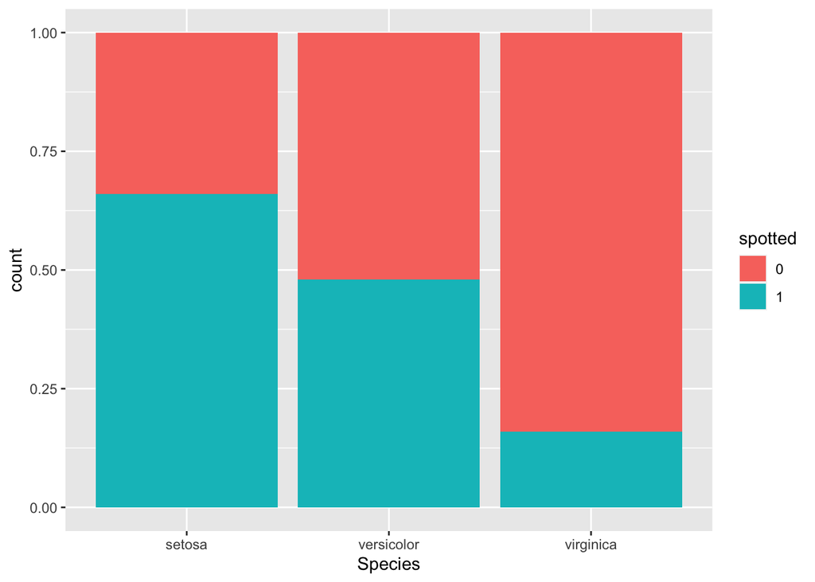

```r
ggplot(iris,
       aes(fill = spotted, x = Species)) +
  geom_bar(position = "fill")
```

Figure 1: The proportion of each species that is spotted.

$$\begin{equation}
\tag{1}
f(y|x_{1}) = \frac{\text{prior . likelihood}}{\text{normalizing constant}} = \frac{f(y)L(y|x_{1})}{f(x_{1})}
\end{equation}$$

where, by the Law of Probability,

$$\begin{equation}
\tag{2}
\quad f(x_{1}) = \sum_{\text{all } y^{'}} f(y^{'}) L(y^{'}|x_{1}) \\
\
= f(y^{'} = Se)L(y^{'} = Se|x_{1}) + f(y^{'} = Ve)L(y^{'} = Ve|x_{1}) + f(y^{'} = Vi)L(y^{'} = Vi|x_{1}).
\end{equation}$$

We can easily calculate this via the frequency table which breaks down the spotted variable by Species:

```r
# frequency table
iris %>%
  select(Species, spotted) %>%
  tabyl(Species, spotted) %>%
  adorn_totals(c("row", "col"))
```

```
##     Species  0  1 Total
##      setosa 17 33    50
##  versicolor 26 24    50
##   virginica 42  8    50
##       Total 85 65   150
```

Based on the frequency table, we can calculate the posterior model of the Iris flower. **Given the fact that all three species have the same probability of being found in nature** , our Iris flower is most likely to be Setosa and less likely to be Virginica. Let’s go step by step to calculate the each posterior probabilities that this flower belong to the each species.

First, our prior information about species membership indicates that all of the species are equally common:

$$f(y = Se) = \frac{50}{150}, \qquad f(y = Ve) = \frac{50}{150}, \qquad f(y = Vi) = \frac{50}{150}$$

However, the likelihoods show that spotted flowers are most common among Setosa and least common among Virginica:

$$L(y=Se | x_{1} = 1) = \frac{33}{50} \approx 0.66 \\
L(y=Ve | x_{1} = 1) = \frac{24}{50} \approx 0.48 \\
L(y=Vi | x_{1} = 1) = \frac{8}{50} \approx 0.16$$

Inserting these priors and likelihoods into the equation$1$, the total probability of observing a spotted Iris flower across all species is:

$$f(x_{1} = 1) = \frac{50}{150} . \frac{33}{50} + \frac{50}{150} . \frac{24}{50} + \frac{50}{150} . \frac{8}{50} = \frac{65}{150}$$

Finally by Bayes’ Rule we can confirm that there is a 51% probability posterior chance that this Iris flower is Setosa:

$$f(y = Se | x_{1} = 1) = \frac{f(y=Se)L(y = Se | x_{1} = 1)}{f(x_{1} = 1)} \\
= \frac{(50/150) . (33/50)} {65/150} \\
\approx 0.5077$$

Posterior probabilities that this Iris flower is Versicolor or Virginica can be calculated as in the same way:
$$f(y = Ve | x_{1} = 1) \approx 0.3692 \quad \text{and} \quad f(y = Vi | x_{1} = 1) \approx 0.1231$$

As a result, the naive Bayes classification, based on our prior information and the fact that the flower is spotted, is that this flower is a Setosa. Although the results showed that this flower is more likely to be a Setosa, the probability that this is flower is a Versicolor (37%) is also not very low. In this sense, using also other physical characteristics of the flower can give us a better classification results.

One Continuous Predictor

In this part, we will ignore that the flower is spotted and just consider one of its quantitative physical characteristics; Petal.Length = 5.

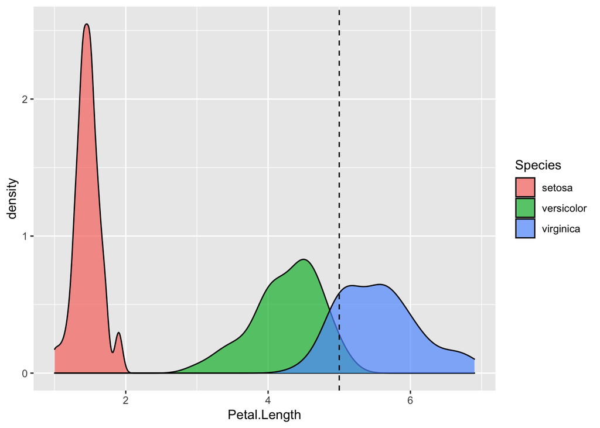

```r
ggplot(iris, aes(x = Petal.Length, fill = Species)) +
  geom_density(alpha = 0.7) +
  geom_vline(xintercept = 5, linetype= "dashed")
```

Figure 2: Density plots of Petal Lengths (cm) observed among three Iris species.

By analyzing the plot, it can be seen that a 5cm-long Petal Length would be extremely long for a Setosa flower. Although, the difference in terms of Petal Length is less dramatic among Versicolor and Virginica, Virginica flowers have relatively longer Petal Length compared to Versicolor flowers. In particular, 5cm-long Petal Length is slightly long for Versicolor species and slightly short for Virginica species. However, this phenomenon is less extreme for Virginica species. Again, **given the fact that all three species have the same probability of being found in nature** , our Iris flower is most likely to be a Virginica and less likely to be a Setosa. By considering this, we can apply the Bayes’ Rule to make a Bayes classficiation of $Y$ from information that Petal Length $X_{4} = x_{4}$:

$$\begin{equation}
\tag{3}
f(y|x_{4}) = \frac{f(y)L(y|x_{4})}{f(x_{4})} = \frac{f(y)L(y|x_{4})}{\sum_{\text{all } y^{'}} f(y^{'}) L(y^{'}|x_{4})}
\end{equation}$$

Here, the question is: What is the likelihood that we would observe a 5cm-long Petal Length if the flower is a Virginica, $L(y=Vi|x_{4} = 5)$? Unlike the flower’s categorical physical characteristic, being spotted or not ($X_{1}$), its Petal Length is a continuous variable. Hence, we cannot simply calculate $L(y=Vi|x_{4} = 5)$ from the frequency table of Species vs Petal.Length. Furthermore, we have not assumed a model for data $X_{4}$ from which to define likelihood function $L(y|x_{4})$. This is where the “naive” part of the Bayes classification comes to play. By using naive Bayes we assume that any quantitative variable which is $X_{4}$ in this case, is **continuous** and **conditionally normal**. Particularly, within each species, Petal Length $X_{4}$ is normally distributed with possibly different means $\mu$ and standard deviations $\sigma$:

$$X_{4}|(Y=Se) \approx N(\mu_{Se}, \sigma^{2}_{Se}) \\
X_{4}|(Y=Ve) \approx N(\mu_{Ve}, \sigma^{2}_{Ve}) \\
X_{4}|(Y=Vi) \approx N(\mu_{Vi}, \sigma^{2}_{Vi}) \\$$

Although making this assumption sounds very “naive” or incorrect, if we examine the Figure 2, Petal Lengths are roughly bell shaped around different means and with different standard deviations. Hence, we can actually set a normal model for each species by setting its $\mu$ and $\sigma$ parameters to the observed sample means and standard devaitions in Petal Lengths within that species. For instance we will assume that Petal Length for Virginica species is normally distributed with $\mu_{Vi} = 5.55$cm and $\sigma_{Vi} = 0.55$cm:

```r
# Calculate sample mean and sd for each Y group
iris %>%
  group_by(Species) %>%
  summarize(mean = mean(Petal.Length, na.rm = TRUE),
            sd = sd(Petal.Length, na.rm = TRUE))
```

```
## # A tibble: 3 × 3
##   Species     mean    sd
##   <fct>      <dbl> <dbl>
## 1 setosa      1.46 0.174
## 2 versicolor  4.26 0.470
## 3 virginica   5.55 0.552
```

Now, we will plot the tuned normal models for each species. Even though the tuned models are not perfect, they are more idealistic and convenient than the density plots of the raw data as in the Figure 2.

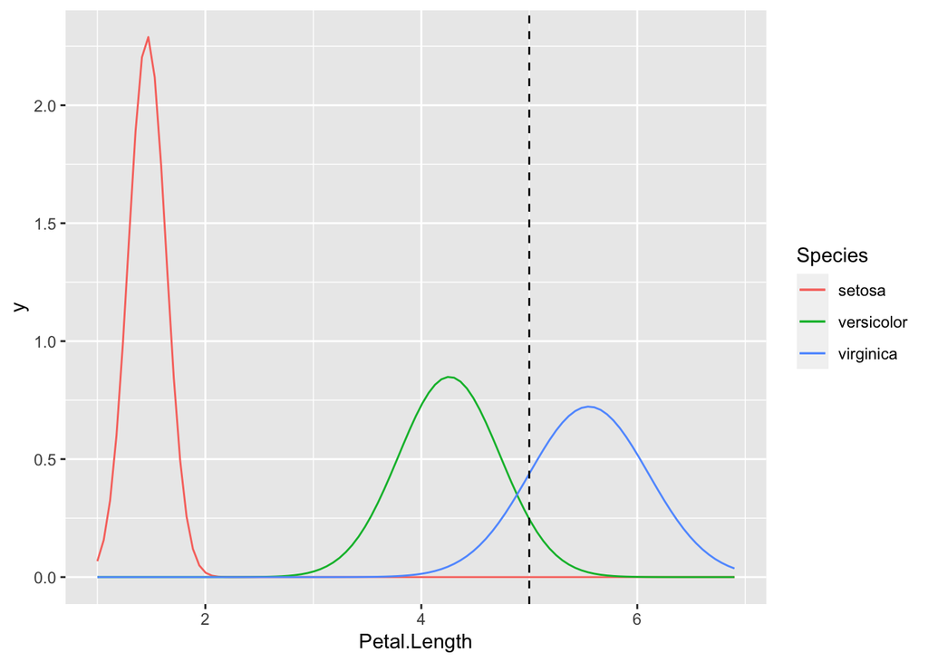

```r
#Plotting the tuned Normal models
ggplot(iris, aes(x = Petal.Length, color = Species)) +
  stat_function(fun = dnorm, args = list(mean = 1.462, sd = 0.174),
                aes(color = "setosa")) +
  stat_function(fun = dnorm, args = list(mean = 4.260, sd = 0.470),
                aes(color = "versicolor")) +
  stat_function(fun = dnorm, args = list(mean = 5.552, sd = 0.552),
                aes(color = "virginica")) +
  geom_vline(xintercept = 5, linetype ="dashed")
```

Figure 3: Normal probability density functions tuned to match the observed mean and standard deviation in Petal Length (cm) among three Iris species.

By looking at the Figure 3, observing a 5cm long Petal Length is more likely to among Virginica than Versicolor and it is very unlikely to among Setosa species. Thus, we can calculate the likelihoods using the function dnorm().

```r
#L(y = Se | x_4 = 5)
dnorm(5, mean = 1.462, sd = 0.174)
```

```
## [1] 3.819798e-90
```

```r
#L(y = Ve | x_4 = 5)
dnorm(5, mean = 4.260, sd = 0.470)
```

```
## [1] 0.2457622
```

```r
#L(y = Vi | x_4 = 5)
dnorm(5, mean = 5.552, sd = 0.552)
```

```
## [1] 0.4383528
```

Now we can apply the Bayes’ Rule (Equation 1) by weighting the likelihood by the prior probabilities of each species. The marginal probability density function of observing an Iris flower with a 5cm Petal Length is:

$$f(x_{4} = 5) = \frac{50}{150}. 0 + \frac{50}{150}. 0.246 + \frac{50}{150}. 0.438 = 0.228$$

Hence, the posterior probability that the Iris flower is a Virginica is:

$$f(y = Vi | x_{4} = 5) = \frac{(50/150). 0.438}{0.228} \approx 0.640$$

Likewise, we can calculate the posterior probabilities that the flower is a Setosa or Versicolor:

$$f(y = Se | X_{4} = 5) \approx 0 \quad \text{and} \quad f(y = Ve | x_{4} = 5) \approx 0.360$$
Based on only the information that the flower’s Petal Length is 5cm, this flower is Virginica with th highest probability (64%). On the other hand, when we do it this classification only with the information regarding whether the flower is spotted or not, the results showed that it is a Setosa. In this sense, using more than one variable can give us a better classification result.

Two Continuous Predictors

In the previous two naive Bayes classifications, we classified the Iris flower; first based on whether it is spotted or not and second based on its 5cm long Petal length These two classifications disagree. We classified the flower as a Setosa in the former one and as a Virginica in the second latter. This disagreement shows that we can improve our classification by including multiple predictors to the model.

In this part, we will consider two continuous predictors to classify the flower of interest. Consider the information that the flower has a Petal length of $X_{4} = 5$ and a Sepal Length of $X_{2} = 6$.

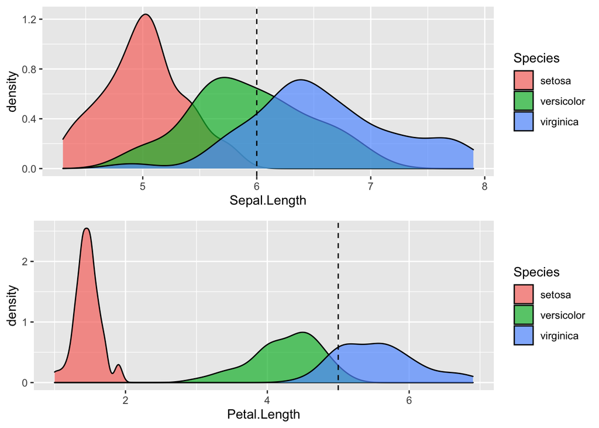

```r
sepal <- ggplot(iris, aes(x = Sepal.Length, fill = Species)) +
  geom_density(alpha = 0.7)  +
  geom_vline(xintercept = 6, linetype = 'dashed')

petal <- ggplot(iris, aes(x = Petal.Length, fill = Species)) +
  geom_density(alpha = 0.7) +
  geom_vline(xintercept = 5, linetype = 'dashed')

ggarrange(sepal, petal, ncol = 1)
```

Figure 4: Density plots of the Sepal and Petal lengths among three Iris species.

Figure 4 shows us that either one of these measures can give us different classification results. However, when we combine the information on Sepal and Petal length, the species become more distinguishable. The Iris flower is represented at the intersection of the dashed lines in the Figure 5.

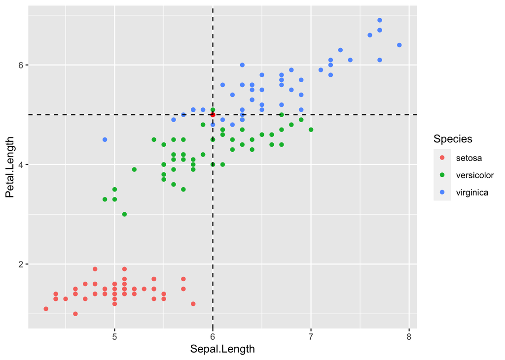

```r
ggplot(iris, aes(x=Sepal.Length, y=Petal.Length, color= Species)) +
  geom_point()+
  geom_point(x=6, y=5, color = "red") +
  geom_vline(xintercept = 6, linetype = "dashed") +
  geom_hline(yintercept = 5, linetype = "dashed")
```

Figure 5: A scatterplot of the Sepal length(cm) versus Petal length(cm) among three Iris species.

Bayes’ Rule can be adjustable for two different predictor variables as follow:

$$f(y|x_{2}, x_{4}) = \frac{f(y)L(y|x_{2}, x_{4})}{\sum_{\text{all } y^{'}} f(y^{'}) L(y^{'}|x_{2}, x_{4})}$$

Now here the question is how we calculate the likelihood function with two variables, $L(y|x_{2}, x_{4})$. As it is shown in the beginning of the document, naive Bayes classification assumes that the predictor variables are **conditionally independent**, hence

$$L(y|x_{2},x_{4}) = f(x_{2}, x_{4}|y) = f(x_{2}|y)f(x_{4}|y)$$

Based on the conditional independence assumption, we assume that Petal length has no relationship to the Sepal length. Mathematically and computationally, this assumption makes the naive Bayes very efficient. On the other hand, it may also make it wrong because actually Sepal and Petal lengths are positively correlated especially for Versicolor and Virginica species (Figure 5). Hence, with this imperfect independence assumption the possibility of an accurate classification might be weakened.

Similar to the classification with one continuous predictor variable, we will tune normal for Petal ($X_{4}$) and Sepal ($X_{2}$) lengths. As we already tuned the model for $X_{4}$, let’s tune the model for $X_{2}$ to match the corresponding sample means and standard deviations:

```r
# Calculate sample mean and sd for each Y group
iris %>%
  group_by(Species) %>%
  summarize(mean = mean(Sepal.Length, na.rm = TRUE),
            sd = sd(Sepal.Length, na.rm = TRUE))
```

```
## # A tibble: 3 × 3
##   Species     mean    sd
##   <fct>      <dbl> <dbl>
## 1 setosa      5.01 0.352
## 2 versicolor  5.94 0.516
## 3 virginica   6.59 0.636
```

Accordingly we can calculate the likelihoods of observing a 6-cm long Sepal length by usign dnorm function:

```r
#L( y = Se | x_2 = 6)
dnorm(6, mean = 5.006, sd = 0.3524897)
```

```
## [1] 0.02123219
```

```r
#L(y = Ve | x_2 = 6)
dnorm(6, mean = 5.936, sd = 0.5161711)
```

```
## [1] 0.7669695
```

```r
#L(y = Vİ | X_2 = 6)
dnorm(6, mean = 6.588, sd = 0.6358796)
```

```
## [1] 0.4091266
```

After having the likelihood of observing a Sepal length of $X_{2} = 6cm$, the likelihood of observing a Petal length of $X_{4} = 5cm$ and the prior probability, we can combine them as:

$$f(y^{'} = Se)L(y^{'} = Se | x_{2} = 6, x_{4} = 5) = \frac{50}{150}. 0.02123219 . 0 \\
f(y^{'} = Ve)L(y^{'} = Ve | x_{2} = 6, x_{4} = 5) = \frac{50}{150}. 0.7669695 . 0.2457622 \\
f(y^{'} = Vi)L(y^{'} = Vi | x_{2} = 6, x_{4} = 5) = \frac{50}{150}. 0.4091266 . 0.4383528$$

with a sum of

$$\sum_{\text{all } y^{'}} f(y^{'}) L(y^{'}|x_{2} = 6, x_{4} = 5) \approx 0.1226113$$
Plugging these into Bayes’ Rule (equation1), the posterior probability that the flower is a Virginica is

$$f(y = Vi | x_{2} = 6, x_{4} = 5) = \frac{\frac{50}{150}. 0.4091266 . 0.4383528}{0.1226113} \approx 0.4875619$$

Similarly the posterior probabilities of the other two species:

$$f(y = Se | x_{2} = 6, x_{4} = 5) \approx 0\\
f(y = Ve | x_{2} = 6, x_{4} = 5) \approx 0.5124381$$
In conclusion the flower is a Versicolor with the probability of %51 and Virginica with a probability of %49. As we can also observe in Figure 5, the flower of interest is at the intersection of Versicolor and Virginica species. Hence, we are almost certain that this flower is not a Setosa, however it is hard to classify the flower between Virginica and Versicolor based on Petal and Sepal lengths.

Implementation of naive Bayes classification

As mentioned above the previous part aims to display how the naive Bayes classifier works. In this section we will implement the naive Bayes classifier with naiveBayes function from the package e1071 by Meyer et al. (2021). Hence, we actually do not need to do all the math work by hand. naiveBayes function calculates the prior probabilities from the data itself and its implementation does not require MCMC simulation which makes the method more efficient also compared to Bayesian Logistic classification. Hence, this method actually provides advantage regarding to prior specification and computational disadvantage occurring in Markov chains.

Now we will implement the naive Bayes by splitting the data into two as train (70%) and test (30%) data. All of the physical characteristics of the species will be used to train the model as well as in the prediction phase. First, let’s split the data:

```r
#make this example reproducible
set.seed(1)

#Use 70% of dataset as training set and remaining 30% as testing set
sample <- sample(c(TRUE, FALSE), nrow(iris), replace=TRUE, prob=c(0.7,0.3))
train  <- iris[sample, ]
test   <- iris[!sample, ]
```

Now we can train our model as:

```r
naive_model <- naiveBayes(Species ~ ., data = train)
```

The predict function returns the posterior probabilities of each species along with the final classifications. By specifying type variable of the function as “raw”, you can see the posterior probabilities. In default, predict function returns the final classifications. This classification follows a simple rule: classify the flower as whichever species has that highest posterior probability.

```r
raw <- predict(naive_model, newdata = test, type = "raw")
final <- as.data.frame(predict(naive_model, newdata = test))
preds <- cbind(raw, final)
head(preds)
```

```
##   setosa   versicolor    virginica predict(naive_model, newdata = test)
## 1      1 1.439066e-22 6.266677e-24                               setosa
## 2      1 1.945383e-18 2.131886e-20                               setosa
## 3      1 1.704304e-22 1.036095e-23                               setosa
## 4      1 3.177839e-24 6.116342e-24                               setosa
## 5      1 1.879750e-21 1.997967e-22                               setosa
## 6      1 5.594481e-22 2.271434e-23                               setosa
```

Model Performance Evaluation

Two common methods are used to evaluate the accuracy of these classifications;

- **Confusion matrices** to compare the true species of the test data to their naive Bayes species classifications

```r
ConfMat <- table(test$Species, final[[1]])
confusionMatrix(ConfMat)
```

```
## Confusion Matrix and Statistics
##
##
##              setosa versicolor virginica
##   setosa         16          0         0
##   versicolor      0         16         0
##   virginica       0          1        11
##
## Overall Statistics
##
##                Accuracy : 0.9773
##                  95% CI : (0.8798, 0.9994)
##     No Information Rate : 0.3864
##     P-Value [Acc > NIR] : < 2.2e-16
##
##                   Kappa : 0.9655
##
##  Mcnemar's Test P-Value : NA
##
## Statistics by Class:
##
##                      Class: setosa Class: versicolor Class: virginica
## Sensitivity                 1.0000            0.9412           1.0000
## Specificity                 1.0000            1.0000           0.9697
## Pos Pred Value              1.0000            1.0000           0.9167
## Neg Pred Value              1.0000            0.9643           1.0000
## Prevalence                  0.3636            0.3864           0.2500
## Detection Rate              0.3636            0.3636           0.2500
## Detection Prevalence        0.3636            0.3636           0.2727
## Balanced Accuracy           1.0000            0.9706           0.9848
```

Confusion matrix is a very classical way of evaluating the performance of the model prediction. In words,16 Setosa an 16 Versicolor are classified correctly. Out of 12 Virginica, 11 Virginica are classified correctly and 1 Virginica classified as Versicolor. Hence, the predictive power of the model seems quite high also as it is shown by high accuracy, sensitivity and specificity rates.

- 10-fold **Cross validation** can also be used to evaluate and compare how well naive_model classifies other Iris flowers not just those in the test data. naive_classfication_summary_cv() function from the package bayesrules is used for cross-validation. Note that you can also change the parameter k based on your model and data.

```r
set.seed(84735)
cv_model <- naive_classification_summary_cv(
  model = naive_model, data = iris, y = "Species", k = 10)
```

The cv_model$folds object contains the classfication accuracy rates for each 10 folds whereas cv_model$cv returns the average of the results across all 10 folds:

```r
cv_model$cv
```

```
##     Species       setosa  versicolor   virginica
##      setosa 100.00% (50)  0.00%  (0)  0.00%  (0)
##  versicolor   0.00%  (0) 92.00% (46)  8.00%  (4)
##   virginica   0.00%  (0)  6.00%  (3) 94.00% (47)
```

The accuracy rates of cross-validated confusion matrix are comparable to those in the non-validated confusion matrix above. Hence, the naive Bayes model performs as good on new Iris flowers as it does on the original test data.

Concluding Remarks

Naive Bayes classifier is an alternative way for classification problems especially for multi-class predictions with high dimensional data sets. To summarize the advantages of naive Bayes classifier:

- It can classify categorical response variables with two or more categories;
- It does not require much theory beyond Bayes’ rule
- It does not require as much training data
- It handles both continuous and categorical data
- It is very simple and fast to implement (e.g., it does not require MCMC simulation as in Bayesian logistic regression)

However, **conditional independence** assumption does not always hold and in most of the cases predictors show dependency. Furthermore, there can be sometimes **zero probability** problem. As naive Bayes computationally very efficient especially with high dimensional data sets, it is a convenient option for spam filtration, sentimental analysis and text classification problems. However, these data sets are not very clean or structured as Iris dataset in our example. Hence, for instance, when we encounter new words in the test data for a particular class that are not present in the training data, we might end up with zero probabilities which makes the model unable to make prediction. This problem can be solved through **smoothing technique** where we add a small smoothing factor to the numerator and denominator of every probability to avoid zero even for new words.

Overall, if the main aim is to classify the outcome rather than explaining the relationship among the variables, you should decide to use naive Bayes classification based on your dataset characteristics such as data size and multicolliniarity among predictor variables. You can also use different classification methods and compare their performance using confusion matrices.

References

Cestnik, B., Kononenko, I., & Bratko, I. (1987, May). ASSISTANT 86: A knowledge-elicitation tool for sophisticated users. In Proceedings of the 2nd European conference on European working session on learning (pp. 31-45).

Domingos, P., & Pazzani, M. (1996, July). Beyond independence: Conditions for the optimality of the simple bayesian classi er. In Proc. 13th Intl. Conf. Machine Learning (pp. 105-112). ISO 690

Meyer, David, Evgenia Dimitriadou, Kurt Hornik, Andreas Weingessel, and Friedrich Leisch. 2021. E1071: Misc Functions of the Department of Statistics, Probability Theory Group (Formerly: E1071), TU Wien. https://CRAN.R-project.org/package=e1071.

Soria, D., Garibaldi, J. M., Ambrogi, F., Biganzoli, E. M., & Ellis, I. O. (2011). A ‘non-parametric’ version of the naive Bayes classifier. Knowledge-Based Systems, 24(6), 775–784. https://doi.org/10.1016/j.knosys.2011.02.014

Tsangaratos, P., & Ilia, I. (2016). Comparison of a logistic regression and Naïve Bayes classifier in landslide susceptibility assessments: The influence of models complexity and training dataset size. CATENA, 145, 164–179. https://doi.org/10.1016/j.catena.2016.06.004